# When measurement precision is constant, differences in $q$-values between methods should be driven by estimates of $\pi_0$

Here we explore the root cause of differences between $q$-values produced by different methods, in the simple case where measurement precisions $(se(\hat\beta_j))$ are the same for all observations. We claim that these differences should be driven primarily by the fact that different methods produce different estimates for $\pi_0$, rather than other differences in methodology.

First, we outline the intuition behind why differences should be driven primarily by differences in $\pi_0$. Suppose we are given a set of $n$ $p$-values corresponding to $n$ distinct null hypotheses. Given an estimate of the proportion of true nulls, $\pi_0$, the false discovery rate at threshold $p$, FDR($p$), is easily estimated “non-parametrically” using the fact that the expected number of false discoveries at threshold $p$ is $n p \pi_0$. The $q$-value for observation $j$ is then, by definition, $q_j = \text{FDR}(p_j)$. This simple “non-parametric” approach to computing $q$-values is implemented in the following function:

```r
  qval.nonp = function(p,pi0){
    n =length(p)
    efp = n*p*pi0 # expected number of false positives at threshold p
    np =  rank(p) #number of positives
    return(efp/np)
  }
```

This approach is sufficiently straightforward and natural that one might make the following claim: any method that, using the same value $\pi_0$, produces appreciably different $q$-values from the non-parametric approach, should be considered with suspicion (or at least with caution). This would in turn imply that differences between (sensible) methods should be driven by differences in $\pi_0$, since if they have the same $\pi_0$ then they should both produce results similar to the simple nonparametric approach.

This said, the method for computing $q$-values in `ash` is, on the face of it, very different from the non-parametric approach, and so it is not clear in advance that the two will match closely. In `ash` $q$-values are computed by first computing the local false discovery rate (lfdr) for each observation, and then, at any given threhold, averaging the lfdr values that exceed this threshold to estimate the $q$-value at that threshold. This approach is effectively estimating a tail-area (the $q$ value) by first estimating a density (the lfdr) and then approximating an integral (by averaging). From this viewpoint, `ash` tackles an easy problem (estimating a tail area) by first solving a harder problem (estimating a density), and one might worry that this could introduce errors.

We examine this issue by simulation. First we define a simple simulation function that simulates a mixture of 0 and non-zero (normally-distributed) beta values.

```r
  # simulate n beta-hat values, nnull under the null with altmean and altsd
  # being the mean and sd of beta under the alternative
  simdata = function(n, nnull, altmean, altsd, betahatsd) {
    null = c(rep(1, nnull), rep(0, n - nnull))
    beta = c(rep(0, nnull), rnorm(n - nnull, altmean, altsd))
    betahat = rnorm(n, beta, betahatsd)
    return(list(null = null, beta = beta, betahat = betahat, betahatsd = betahatsd))
  }
  library(ashr)
  library(qvalue)
  library(locfdr)
  library(mixfdr)
  library(knitr)
```

In our first simulation, half the $\beta_j$ are null, and the other half are $\beta_j \sim N(0,2^2)$. Then $\hat\beta_j \sim N(\beta_j, 1)$. We apply `qvalue`,`ash`,`locfdr` and `mixFdr` to estimate the $q$-values. (The last three methods all estimate local fdr values; we convert these to corresponding estimated $q$ values using the `ashr` function `qval.from.lfdr`, which, for each observation $j$, computes the $q$ value as the average of the lfdr values more significant than observation $j$.)

```r
  set.seed(100)
  test = simdata(10000, 5000, 0, 2, 1)
  test.ash = ash(test$betahat,test$betahatsd)
  test.ash.hu = ash(test$betahat,test$betahatsd,mixcompdist="halfuniform")
  z = test$betahat/test$betahatsd
  p = pchisq(z^2, df=1,lower.tail=FALSE)
  test.qv = qvalue(p)
  test.locfdr = locfdr(z,nulltype=0,plot=0)
  test.locfdr.qval = qval.from.lfdr(test.locfdr$fdr)
  test.mixfdr = mixFdr(z,theonull=TRUE,noiseSD=1,plots=FALSE)
  test.mixfdr.qval = qval.from.lfdr(test.mixfdr$fdr)
```

The estimates of $\pi_0$ from the four methods are given in the following table:

```r
  kable(data.frame(method=c("qvalue","ash","locfdr","mixfdr"),pi0=round(c(test.qv$pi0,get_pi0(test.ash),test.locfdr$fp0[1,3],test.mixfdr$pi[1]),digits=2)))
```

| method | pi0 |
| --- | --- |
| qvalue | 0.72 |
| ash | 0.57 |
| locfdr | 0.73 |
| mixfdr | 0.85 |

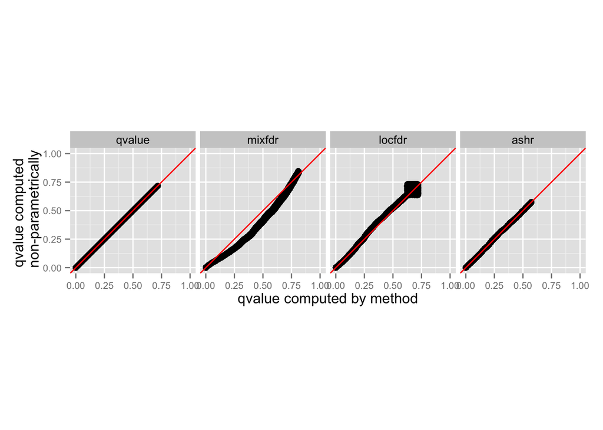

```r
  res = rbind(data.frame(method="qvalue",q = test.qv$qvalues, qnonp = qval.nonp(p,test.qv$pi0)),
         data.frame(method="mixfdr",q = test.mixfdr.qval, qnonp = qval.nonp(p,test.mixfdr$pi[1])),
         data.frame(method="locfdr",q = test.locfdr.qval, qnonp = qval.nonp(p,test.locfdr$fp0[1,3])),

         data.frame(method="ashr",q = test.ash$qvalue, qnonp = qval.nonp(p,get_pi0(test.ash)))
         )
  library(ggplot2)
  ggplot(res, aes(x=q, y=qnonp)) + facet_grid(.~method) + geom_point(shape=1) +xlim(0,1) +ylim(0,1) + xlab("qvalue computed by method") +ylab("qvalue computed \n non-parametrically") +geom_abline(slope=1,intercept=0,color=2) + coord_equal() + theme(axis.text.x  = element_text(size=8), axis.text.y  = element_text(size=8))
```

```r
  ggsave("qval_comparison.png", width=8, height=2, dpi=100)
```

```r
  set.seed(100)
  test = rbind(data.frame(simdata(5000, 2500, 2, 1, 1)), data.frame(simdata(5000,2500,-2,1,1)))
  test.ash = ash(test$betahat,test$betahatsd)

  z = test$betahat/test$betahatsd
  p = pchisq(z^2, df=1,lower.tail=FALSE)
  test.qv = qvalue(p)
  test.locfdr = locfdr(z,nulltype=0,plot=0)
  test.locfdr.qval = qval.from.lfdr(test.locfdr$fdr)
  test.mixfdr = mixFdr(z,theonull=TRUE,noiseSD=1,plots=FALSE)
```

```
## Fitting preliminary model
## Fitting final model
```

```
##
## Fitted Model: J = 3 groups
## ----------------------------
## null?         TRUE   FALSE   FALSE
##
## pi =     0.7762  0.1126  0.1112
##
## mu =          0.000  -2.945   2.971
##
## sigma =  1.000   1.029   1.023
##
## noiseSD =    1
```

```r
  test.mixfdr.qval = qval.from.lfdr(test.mixfdr$fdr)
  kable(data.frame(method=c("qvalue","ash","locfdr","mixfdr"),pi0=round(c(test.qv$pi0,get_pi0(test.ash),test.locfdr$fp0[1,3],test.mixfdr$pi[1]),digits=2)))
```

| method | pi0 |
| --- | --- |
| qvalue | 0.62 |
| ash | 0.44 |
| locfdr | 0.66 |
| mixfdr | 0.78 |

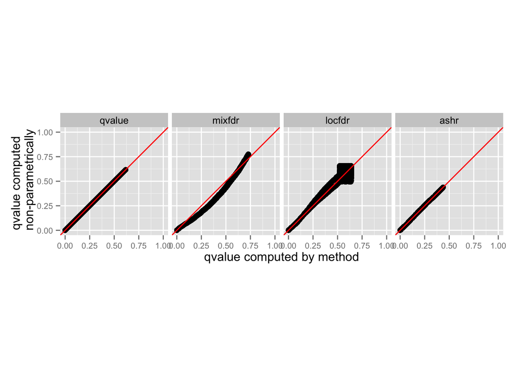

```r
  res = rbind(data.frame(method="qvalue",q = test.qv$qvalues, qnonp = qval.nonp(p,test.qv$pi0)),
         data.frame(method="mixfdr",q = test.mixfdr.qval, qnonp = qval.nonp(p,test.mixfdr$pi[1])),
         data.frame(method="locfdr",q = test.locfdr.qval, qnonp = qval.nonp(p,test.locfdr$fp0[1,3])),

         data.frame(method="ashr",q = test.ash$qvalue, qnonp = qval.nonp(p,get_pi0(test.ash)))
         )
  library(ggplot2)
  ggplot(res, aes(x=q, y=qnonp)) + facet_grid(.~method) + geom_point(shape=1) +xlim(0,1) +ylim(0,1) + xlab("qvalue computed by method") +ylab("qvalue computed \n non-parametrically") +geom_abline(slope=1,intercept=0,color=2) + coord_equal() + theme(axis.text.x  = element_text(size=8), axis.text.y  = element_text(size=8))
```

```r
  ggsave("qval_comparison_nonUA.png", width=8, height=2, dpi=100)
```

Although these simulations are by no-means comprehensive, they show that, for these the primary difference between ash $q$ values and qvalue $q$ values is the different estimates of $\pi_0$.